# disgenet2r: An R package to explore the molecular underpinnings of human diseases

IBI group

2021-08-05

# Introduction

The **disgenet2r** package contains a set of functions to retrieve, visualize and expand DisGeNET data. DisGeNET is a discovery platform that contains information about the genetic basis of human diseases (J. Piñero et al. 2015, 2017; Janet Piñero et al. 2019). DisGeNET integrates data from several expert curated databases and from text-mining the biomedical literature.

The current version of DisGeNET (v7.0) contains 1134942 gene-disease associations (GDAs), between 21671 genes and 30170 diseases, disorders, traits, and clinical or abnormal human phenotypes, and 369554 variant-disease associations (VDAs), between 194515 variants and 14155 diseases, traits, and phenotypes.

The information in DisGeNET is organized according to the original data source (Table 1). Diseases are identified using the UMLS concept unique identifier (CUI), but mappings to commonly employed biomedical vocabularies such as MeSH, OMIM, DO, HPO, and ICD-9 are also provided. The genes are identified using the NCBI Entrez Identifier, but annotations to the official gene symbol, the UniProt identifier, and the Panther Protein Class are also supplied. Finally, the GDAs and VDAs can be ranked using the DisGeNET score. The DisGeNET score ranges from 0 to 1, and takes into account the evidence supporting the association (See more information at http://disgenet.org/dbinfo/)

DisGeNET data is also represented as a Resource Description Framework (RDF), which provides new opportunities for data integration, making possible to link DisGeNET data to other external RDF datasets (Queralt-Rosinach et al. 2016).

Table: Sources of DisGeNET data

| Source_Name | Type_of_data | Description |
| --- | --- | --- |
| CTD_human | GDAs | The Comparative Toxicogenomics Database, human data |
| CGI | GDAs | The Cancer Genome Interpreter |
| CLINGEN | GDAs | The Clinical Genome Resource |
| GENOMICS_ENGLAND | GDAs | The Genomics England PanelApp |
| ORPHANET | GDAs | The portal for rare diseases and orphan drugs |
| PSYGENET | GDAs | Psychiatric disorders Gene association NETwork |
| HPO | GDAs | Human Phenotype Ontology |
| UNIPROT | GDAs/VDAs | The Universal Protein Resource |
| CLINVAR | GDAs/VDAs | ClinVar, public archive of relationships among sequence variation and human phenotype |
| GWASCAT | GDAs/VDAs | The NHGRI-EBI GWAS Catalog |
| GWASDB | GDAs/VDAs | The GWas Database |
| CTD_mouse | GDAs | The Comparative Toxicogenomics Database, Mus musculus data |
| MGD | GDAs | The Mouse Genome Database |
| CTD_rat | GDAs | The Comparative Toxicogenomics Database, Rattus norvergicus data |
| RGD | GDAs | The Rat Genome Database |
| BEFREE | GDAs/VDAs | Data from text mining medline abstracts using the BeFree System (Bravo et al. 2015) |
| LHGDN | GDAs | Literature-derived human gene-disease network generated by text mining NCBI GeneRIFs (Bundschus et al. 2008) |
| CURATED | GDAs/VDAs | Human curated sources: CTD, ClinGen, CGI, UniProt, Orphanet, PsyGeNET, Genomics England PanelApp |
| INFERRED | GDAs | Inferred data from: HPO,ClinVar, GWASCat, GwasDB |
| ANIMAL_MODELS | GDAs | Data from animal models: CTD_rat, RGD, CTD_mouse, MGD |
| ALL | GDAs/VDAs | All data sources |

# Contact

For questions regarding **disgenet2r**, contact our support account at support@disgenet.org.

# Installation and first run

The package **disgenet2r** is available through Bitbucket. The package requires an R version > 3.5. Additionally, the following packages are needed: VennDiagram, stringr, tidyr, SPARQL, RCurl, igraph, ggplot2, and reshape2.

Install **disgenet2r** by typing in R:

```r
library(devtools)
install_bitbucket("ibi_group/disgenet2r")
```

To load the package:

```r
library(disgenet2r)
```

To be able to use the **disgenet2r** package, you need to register for a free account [here](http://disgenet.org/signup). Once you have completed the registration process, use the **get_disgenet_api_key** to retrieve your API key.

```r
disgenet_api_key <- get_disgenet_api_key(
                  email = "user@email.com",
                  password = "myspwd" )
```

After retrieving the API key, run the line below so the key is available for all the **disgenet2r** functions.

```r
Sys.setenv(DISGENET_API_KEY= disgenet_api_key)
```

In the following document, we illustrate how to use the **disgenet2r** package through a series of examples.

# Retrieving Gene-Disease Associations from DisGeNET

## Searching by gene

The **gene2disease** function retrieves the GDAs in DisGeNET for a given gene, or a for a list of genes. The gene(s) can be identified by either the NCBI gene identifier, or the official Gene Symbol, and the type of identifier used must be specified using the parameter `vocabulary`. By default, `vocabulary = "HGNC"`, to switch to Entrez NCBI Gene identifiers, set vocabulary to *ENTREZ*.

The information can be filtered using the DisGeNET score. The argument `score` is filled with a range of score to perform the search. The score is entered as a vector which first position is the initial value of score, and the second argument is the final value of score. Both values will always be included. By default, `score=c(0,1)`.

```r
data1 <- gene2disease( gene = 3953, vocabulary = "ENTREZ",
                       database = "CURATED")
```

The function **gene2disease** produces an object `DataGeNET.DGN` that contains the results of the query.

```r
class(data1)
```

```
## [1] "DataGeNET.DGN"
## attr(,"package")
## [1] "disgenet2r"
```

```r
data1
```

```
## Object of class 'DataGeNET.DGN'
##  . Search:      single
##  . Type:        gene-disease
##  . Database:     CURATED
##  . Score:        0-1
##  . Term:        3953
##  . Results:  79
```

To obtain the data frame with the results of the query, apply the **extract** function:

```r
results <- extract(data1)
head( results, 3 )
```

```
##   gene_dpi geneid gene_symbol protein_class_name gene_pli  source score protein_class disease_type diseaseid year_final uniprotid
## 1    0.808   3953        LEPR          Signaling  0.99475 CURATED  0.72  DTO_05007599      disease  C3554225       2019    P48357
## 2    0.808   3953        LEPR          Signaling  0.99475 CURATED  0.70  DTO_05007599      disease  C0028754       2019    P48357
## 3    0.808   3953        LEPR          Signaling  0.99475 CURATED  0.60  DTO_05007599      disease  C0011860       2019    P48357
##                               disease_name year_initial disease_semantic_type     el    ei
## 1               LEPTIN RECEPTOR DEFICIENCY         1998   Disease or Syndrome strong 1.000
## 2                                  Obesity         1966   Disease or Syndrome        0.930
## 3 Diabetes Mellitus, Non-Insulin-Dependent         1966   Disease or Syndrome        0.975
##                                                                      disease_class_name disease_class gene_dsi
## 1                                                                                                        0.433
## 2    Pathological Conditions, Signs and Symptoms;    Nutritional and Metabolic Diseases       C23;C18    0.433
## 3                      Nutritional and Metabolic Diseases;    Endocrine System Diseases       C18;C19    0.433
```

[output not shown]

### Visualizing the diseases associated to a single gene

The **disgenet2r** package offers two options to visualize the results of querying DisGeNET for a single gene: a network showing the diseases associated to the gene of interest (`Gene-Disease Network`), and a network showing the MeSH Disease Classes of the diseases associated to the gene (`Gene-Disease Class Network`). These graphics can be obtained by changing the `class` argument in the plot function.

By default, the **plot** function produces a `Gene-Disease Network` on a `DataGeNET.DGN` object (Figure 1). In the `Gene-Disease Network` the blue nodes are diseases, the pink nodes are genes, and the width of the edges is proportional to the score of the association. The `prop` parameter allows to adjust the width of the edges while keeping the proportionality to the score.

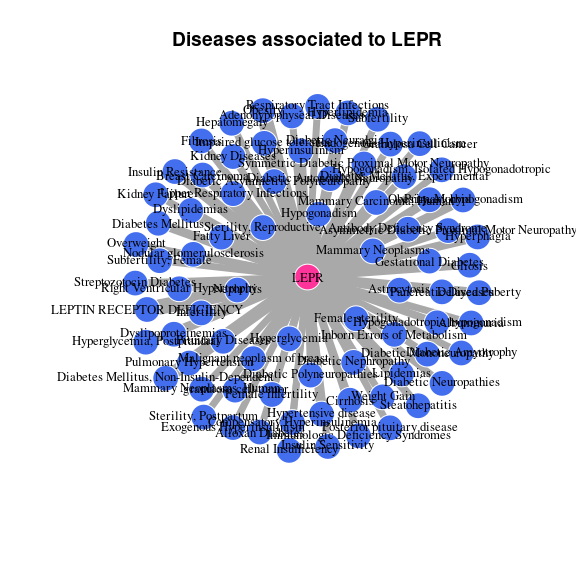

Figure 1: The **Gene-Disease Network** for the Leptin Receptor gene

```r
plot( data1,
      class = "Network",
      prop = 20)
```

```
## [1] "warning: 1 disease(s) not shown in the plot"
```

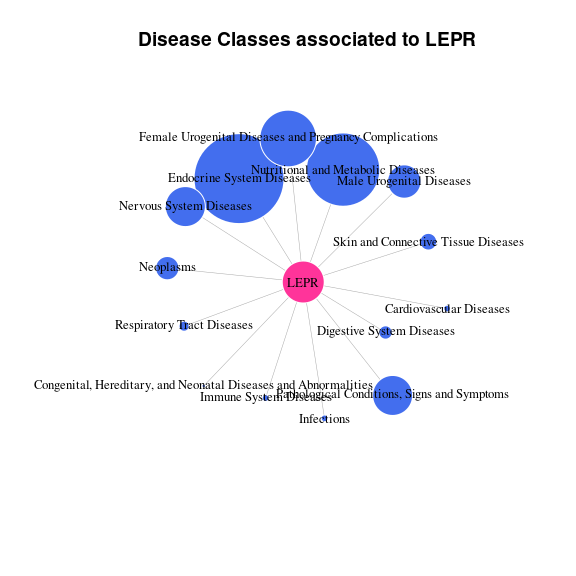

Figure 2: The **Disease Class Network** for the Leptin Receptor Gene

```r
plot( data1,
      class = "DiseaseClass",
      prop = 3)
```

### Exploring the evidences associated to a gene

You can extract the evidences associated to a particular gene using the function **gene2evidence**. Additionally, you can explore the evidences for a specific gene-disease pair by specifying the disease identifier using the argument `disease`.

```r
data1 <- gene2evidence( gene = "LEPR",
                        vocabulary = "HGNC",
               disease ="C3554225",
                       database = "ALL",
                       score =c(0.3,1))
data1
```

```
## Object of class 'DataGeNET.DGN'
##  . Search:      single
##  . Type:        evidence
##  . Database:     ALL
##  . Score:        0.3-1
##  . Term:        LEPR
```

```r
results <- extract(data1)
```

The results are shown in the table below.

Evidences supporting the association between LEPR & C3554225

| pmid | year | sentence |
| --- | --- | --- |
| 29568105 | 2018 | A cohort of n = 21 children living in Germany or Austria with monogenic obesity due to congenital leptin deficiency (group LEP, n = 6), leptin receptor deficiency (group LEPR, n = 6) and primarily het… |
| 31702041 | 2019 | In conclusion, activation of the leptin receptor ob‑R is an important pathogenic mechanism of UC, and leptin receptor deficiency may provide resistance against TNBS‑induced colitis by inhibiting the N… |
| 23275530 | 2013 | Homozygous leptin receptor mutation due to uniparental disomy of chromosome 1: response to bariatric surgery. |
| 17229951 | 2007 | Clinical and molecular genetic spectrum of congenital deficiency of the leptin receptor. |
| 9537324 | 1998 | A mutation in the human leptin receptor gene causes obesity and pituitary dysfunction. |
| 25751111 | 2015 | Seven novel deleterious LEPR mutations found in early-onset obesity: a ΔExon6-8 shared by subjects from Reunion Island, France, suggests a founder effect. |
| 9537324 | 1998 | A mutation in the human leptin receptor gene causes obesity and pituitary dysfunction. |

## Searching multiple genes

The **gene2disease** function can also receive a list of genes as input, either as NCBI Gene Identifiers or Gene Symbols. In the example, we show how to create a vector with the Gene Symbols of several genes belonging to the family of voltage-gated potassium channels (Table 2) and then, we apply the function **gene2disease**.

Table 2: Example of voltage-gated potassium channel family members

| Name | Description |
| --- | --- |
| KCNE1 | potassium channel, voltage gated subfamily E regulatory beta subunit 1 |
| KCNE2 | potassium channel, voltage gated subfamily E regulatory beta subunit 2 |
| KCNH1 | potassium channel, voltage gated eag related subfamily H, member 1 |
| KCNH2 | potassium channel, voltage gated eag related subfamily H, member 2 |
| KCNG1 | potassium voltage-gated channel modifier subfamily G member 1 |

Creating the vector with the list of genes belonging to the voltage-gated potassium channel family.

```r
myListOfGenes <- c( "KCNE1", "KCNE2", "KCNH1", "KCNH2", "KCNG1")
```

The **gene2disease** function also requires the user to specify the source database using the argument `database`, and optionally, the DisGeNET `score` can also be applied to filter the results.

```r
data2 <- gene2disease(
  gene     = myListOfGenes,
  score =c(0.2, 1),
  verbose  = TRUE
)
data2
```

```
## Object of class 'DataGeNET.DGN'
##  . Search:      list
##  . Type:        gene-disease
##  . Database:     CURATED
##  . Score:        0.2-1
##  . Term:       KCNE1 ... KCNH2
##  . Results:  51
```

### Visualizing the diseases associated to multiple genes

By default, plotting a `DataGeNET.DGN` resulting of the query with a list of genes produces a `Gene-Disease Network` where the blue nodes are diseases, the pink nodes are genes, and the width of the edges is proportional to the score of the association (Figure 3).

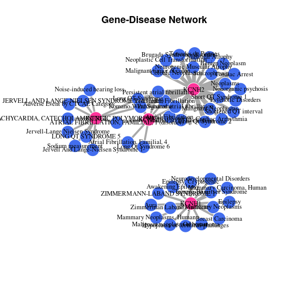

Figure 3: The **Gene-Disease Network** for a list of genes belonging to the voltage-gated potassium channel family

```r
plot( data2,
      class = "Network",
      prop = 10)
```

Setting the argument `class` to “Heatmap” produces a `Gene-Disease Heatmap` (Figure 4), where the scale of colors is proportional to the score of the GDA. The argument `limit` can be used to limit the number of rows to the top scoring GDAs. The argument `nchars` can be used to limit the length of the name of the disease. By default, the plot shows the 50 highest scoring GDAs.

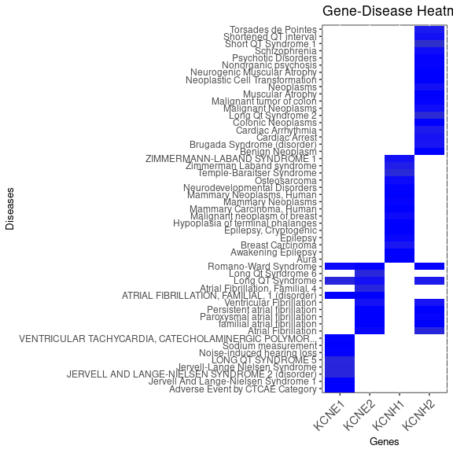

Figure 4: The **Gene-Disease Heatmap** for a list of genes belonging to the voltage-gated potassium channel family

```r
plot( data2,
      class  ="Heatmap",
      limit  = 100, nchars = 50 )
```

```
## [1] "warning: 3 disease(s) not shown in the plot"
```

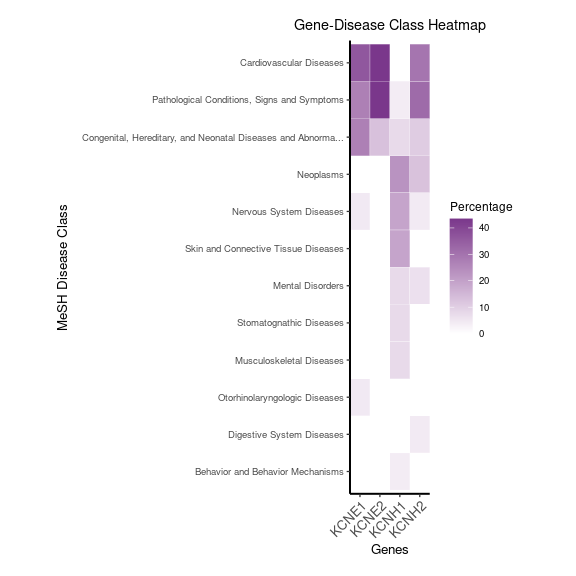

Figure 5: The **Gene-Disease Class Heatmap** for a list of genes belonging to the voltage-gated potassium channel family

```r
plot( data2,
      class="DiseaseClass", nchars=60)
```

## Retrieving the identifier for a disease of interest

To retrieve the concept unique identifier for the disease of interest, you can use the **get_umls_from_vocabulary** function with the parameter vocabulary set to “NAME.” This will retrieve all diseases in DisGeNET that contain the keyword used as an input.

```r
diseases <- get_umls_from_vocabulary( "Schizophrenia", vocabulary = "NAME" )
kable(diseases, caption = "CUIs associated to Schizophrenia") %>%   kable_styling(bootstrap_options = "striped", full_width = F)
```

CUIs associated to Schizophrenia

| diseaseid | name |
| --- | --- |
| C0021151 | Incipient Schizophrenia |
| C0036341 | Schizophrenia |
| C0036344 | Schizophrenia, Catatonic |
| C0036346 | Schizophrenia, Childhood |
| C0036347 | Schizophrenia, Disorganized |
| C0036349 | Paranoid Schizophrenia |
| C0036351 | Residual schizophrenia |
| C0220702 | SCHIZOPHRENIA 1 (disorder) |
| C0221765 | Chronic schizophrenia |
| C0392322 | Undifferentiated schizophrenia |
| C0525046 | Schizophrenia Spectrum and Other Psychotic Disorders |
| C0543918 | SCHIZOPHRENIA 10 |
| C0809983 | Schizophrenia and related disorders |
| C0857501 | Acute schizophrenia |
| C1656427 | Early onset schizophrenia |
| C1833247 | SCHIZOPHRENIA 4 (disorder) |
| C1837893 | SCHIZOPHRENIA 12 |
| C1838069 | SCHIZOPHRENIA 3 (disorder) |
| C1842605 | SCHIZOPHRENIA 11 |
| C1864124 | SCHIZOPHRENIA 8 (disorder) |
| C1864153 | SCHIZOPHRENIA 5 |
| C1864275 | SCHIZOPHRENIA 6 (disorder) |
| C2673482 | Increased susceptibility to schizophrenia |
| C2675945 | SCHIZOPHRENIA, SUSCEPTIBILITY TO |
| C2678117 | Schizophrenia-like symptoms (uncommon) |
| C3151380 | SCHIZOPHRENIA 15 |
| C3544321 | Treatment-resistant schizophrenia |
| C3808913 | SCHIZOPHRENIA 18 |
| C4049474 | Very late onset schizophrenia |
| C4539944 | SCHIZOPHRENIA 19 |

## Searching by disease

The **disease2gene** function allows to retrieve the genes associated to a disease, or a list of diseases. The function uses as input the disease, or list of diseases of interest (as UMLS CUI, MeSH, OMIM, Disease Ontology, ICD9CM, NCIt, EFO, or Orphanet Identifiers), the disease vocabulary employed (`OMIM` (OMIM), `MESH` (MeSH),`ICD9CM` (ICD9-CM), `DO` (Disease Ontology), `NCI` (NCI thesaurus), `ORDO` (Orphanet), or `EFO` (EFO) and the database (by default, `CURATED`). A threshold value for the score can be set, like in the **gene2disease** function.

In the example, we will use the **disease2gene** function to retrieve the genes associated to the UMLS CUI *C0036341*. This function also receives as input the database, in the example, *CURATED*, and a score range, in the example, from 0.4 to 1.

```r
data3 <- disease2gene( disease  = "C0036341",
                          database = "CURATED",
                          score    = c( 0.4,1 ) )
data3
```

```
## Object of class 'DataGeNET.DGN'
##  . Search:      single
##  . Type:        disease-gene
##  . Database:     CURATED
##  . Score:        0.4-1
##  . Term:        C0036341
##  . Results:  227
```

The same results are obtained when querying DisGeNET with the MeSH identifier for Schizophrenia (*D012559*).

```
## Object of class 'DataGeNET.DGN'
##  . Search:      single
##  . Type:        disease-gene
##  . Database:     CURATED
##  . Score:        0.4-1
##  . Term:        D012559
##  . Results:  227
```

The same results are obtained when querying DisGeNET with the OMIM identifier for Schizophrenia (*181500*).

```r
data4 <- disease2gene( disease  = "181500", vocabulary = "OMIM",
                          database = "CURATED",
                          score    = c(0.4,1 ) )
data4
```

```
## Object of class 'DataGeNET.DGN'
##  . Search:      single
##  . Type:        disease-gene
##  . Database:     CURATED
##  . Score:        0.4-1
##  . Term:        181500
##  . Results:  227
```

The same results are obtained when querying DisGeNET with the ICD9-CM identifier for Schizophrenia (*295*).

```r
data4 <- disease2gene( disease  = "295", vocabulary = "ICD9CM",
                          database = "CURATED",
                          score    = c(0.4,1 ) )
data4
```

```
## Object of class 'DataGeNET.DGN'
##  . Search:      single
##  . Type:        disease-gene
##  . Database:     CURATED
##  . Score:        0.4-1
##  . Term:        295
##  . Results:  227
```

The same results are obtained when querying DisGeNET with the NCI identifier for Schizophrenia (*C3362*).

```r
data4 <- disease2gene( disease  = "C3362", vocabulary = "NCI",
                          database = "CURATED",
                          score    = c(0.4,1 ) )
data4
```

```
## Object of class 'DataGeNET.DGN'
##  . Search:      single
##  . Type:        disease-gene
##  . Database:     CURATED
##  . Score:        0.4-1
##  . Term:        C3362
##  . Results:  227
```

```r
data4 <- disease2gene( disease  = "HP:0100753", vocabulary = "HPO",
                          database = "CURATED",
                          score    = c(0.4,1 ) )
data4
```

```
## Object of class 'DataGeNET.DGN'
##  . Search:      single
##  . Type:        disease-gene
##  . Database:     CURATED
##  . Score:        0.4-1
##  . Term:        HP:0100753
##  . Results:  227
```

### Visualizing the genes associated to a single disease

There are two options to visualize the results from searching a single disease: a `Gene-Disease Network` showing the genes related to the disease of interest (Figure 6), and a `Disease-Protein Class Network` with the genes grouped by Panther Protein Class (Figure 7).

Figure 6 shows the default `Gene-Disease Network` for Schizophrenia. As in the case of the **gene2disease** function, the blue nodes is the disease, the pink nodes are genes, and the width of the edges is proportional to the score of the association.

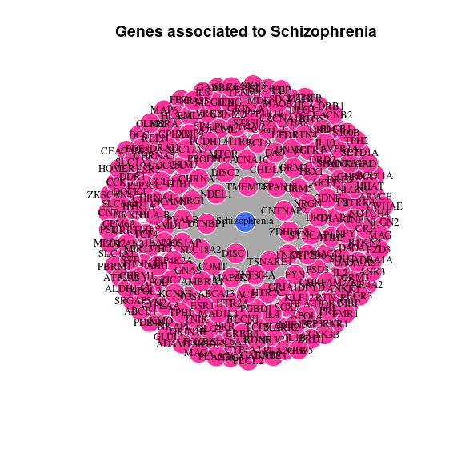

Figure 6: The **Gene-Disease Network** for genes associated to Schizophrenia

```r
plot ( data3,
       prop = 10)
```

```
## [1] "warning: 89 gene(s) not shown in the plot"
```

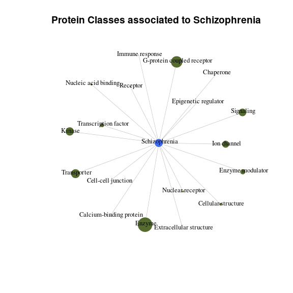

Figure 7: The **Protein Class-Disease Network** for genes associated to Schizophrenia

```r
plot( data3,
      class="ProteinClass"
)
```

### Exploring the evidences associated to a disease

To explore the evidences supporting the associations for Schizophrenia using the function **disease2evidence**.

```r
data3 <- disease2evidence( disease  = "C0036341",
                           type = "GDA",
                          database = "CURATED",
                          score    = c( 0.4,1 ) )
data3
```

```
## Object of class 'DataGeNET.DGN'
##  . Search:      single
##  . Type:        evidence
##  . Database:     CURATED
##  . Score:        0.4-1
##  . Term:        C0036341
```

Additionally, you can explore the evidences for a specific gene-disease pair by specifying the gene identifier using the argument `gene`.

```r
data3 <- disease2evidence( disease  = "C0036341",
                           gene = c("DRD2", "DRD3"),
                           type = "GDA",
                          database = "CURATED",
                          score    = c( 0.4,1 ) )
data3
```

```
## Object of class 'DataGeNET.DGN'
##  . Search:      single
##  . Type:        evidence
##  . Database:     CURATED
##  . Score:        0.4-1
##  . Term:        C0036341
```

```r
results <- extract(data3)
```

The results are shown in the table below.

Evidences supporting the association between C0036341 & DRD2,DRD3

| pmid | year | sentence |
| --- | --- | --- |
| 11245917 | 2001 | Because dopamine D2 receptors are the primary targets for antipsychotic drugs, including clozapine and quetiapine, and because some studies have found D2 receptors to be elevated in schizophrenia, we … |
| 21187413 | 2011 | DRD2/AKT1 interaction on D2 c-AMP independent signaling, attentional processing, and response to olanzapine treatment in schizophrenia. |
| 10523822 | 1999 | Homozygosity at the dopamine DRD3 receptor gene in cocaine dependence. |
| 18583979 | 2008 | Systematic meta-analyses and field synopsis of genetic association studies in schizophrenia: the SzGene database. |
| 10831489 | 2000 | Subjective experience and striatal dopamine D(2) receptor occupancy in patients with schizophrenia stabilized by olanzapine or risperidone. |

## Searching multiple diseases

Table 3: Disease list selected for illustrating the **disease2gene** multiple search

[output not shown]

Creating the vector with the list of diseases.

```r
diseasesOfInterest <- c("C0036341", "C0002395", "C0030567","C0005586")
```

In the example, we will search in *CURATED* data, using a score range of 0.4-1.

```r
data5 <- disease2gene(
  disease = diseasesOfInterest,
  database = "CURATED",
  score =c(0.4,1),
  verbose  = TRUE )
```

### Visualizing the genes associated to multiple diseases

The default plot of the results of querying DisGeNET with a list of diseases produces a `Gene-Disease Network` where the blue nodes are diseases, the pink nodes are genes, and the width of the edges is proportional to the score of the association (Figure 8).

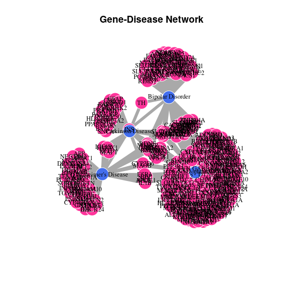

Figure 8: **The Gene-Disease Network** for genes associated to a list of diseases

```r
plot( data5,
      class = "Network",
      prop = 10)
```

To visualize the results as a `Gene-Disease Heatmap` (Figure 9) change the argument `class` to “Heatmap.” In this plot, the scale of colors is proportional to the score of the GDA. The argument `limit` can be used to limit the number of rows to the top scoring GDAs when the results are large. By default, the plot shows the 50 highest scoring GDAs.

```
## [1] "Dataframe of 421 rows has been reduced to 30 rows."
```

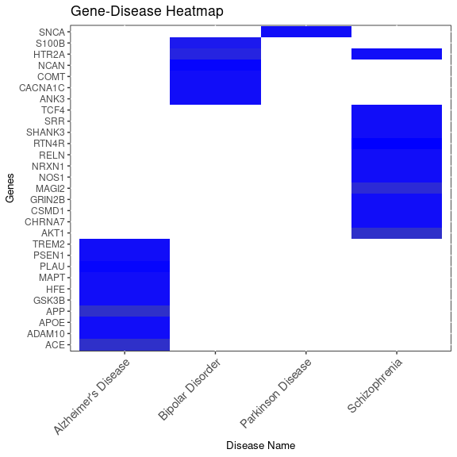

Figure 9: The **Gene-Disease Heatmap** for genes associated to a list of diseases

```r
plot( data5,
      class="Heatmap",
      limit =30,
      cutoff=0.2)
```

A third visualization option is a `Protein Class-Disease Heatmap` (Figure 10), in which genes are grouped by protein class. This plot is obtained by setting the `class` argument to “ProteinClass.” In this case, the color of the heatmap is proportional to the percentage of genes for each disease in each protein class. This heatmap displays the protein classes associated to each disease.

```
## [1] "warning: 142 gene(s) not shown in the plot"
```

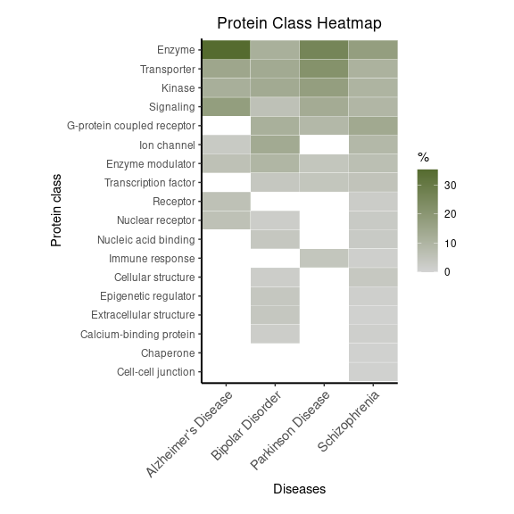

Figure 10: The **Protein Class-Disease** Heatmap for genes associated to a list of diseases

```r
plot( data5,
      class="ProteinClass" )
```

# Retrieving Variant-Disease Associations from DisGeNET

## Searching by variant

The **variant2disease** function receives a variant, or a list of variants as input, identified by the dbSNP identifier. It produces an object `DataGeNET.DGN`, with `Type = "variant-disease"`.

```r
data6 <- variant2disease( variant= "rs121913279",
                         database = "CURATED")
data6
```

```
## Object of class 'DataGeNET.DGN'
##  . Search:      single
##  . Type:        variant-disease
##  . Database:     CURATED
##  . Score:        0-1
##  . Term:        rs121913279
##  . Results:  48
```

### Visualizing the diseases associated to a single variant

The **disgenet2r** package offers several options to visualize the results of querying DisGeNET for a single variant: a `Variant-Disease Network` showing the diseases associated to the variant of interest, a `Variant-Gene-Disease Network` showing the genes, diseases, and variant of interest, and a network showing the MeSH Disease Classes of the diseases associated to the variant (`Variant-Disease Class Network`). These graphics can be obtained by changing the `class` argument in the **plot** function.

By default, the **plot** function produces a `Variant-Disease Network` on a `DataGeNET.DGN` object (Figure 11). In the `Variant-Disease Network` the blue nodes are diseases, the yellow nodes are variants, the blue nodes are diseases, and the width of the edges is proportional to the score of the association.

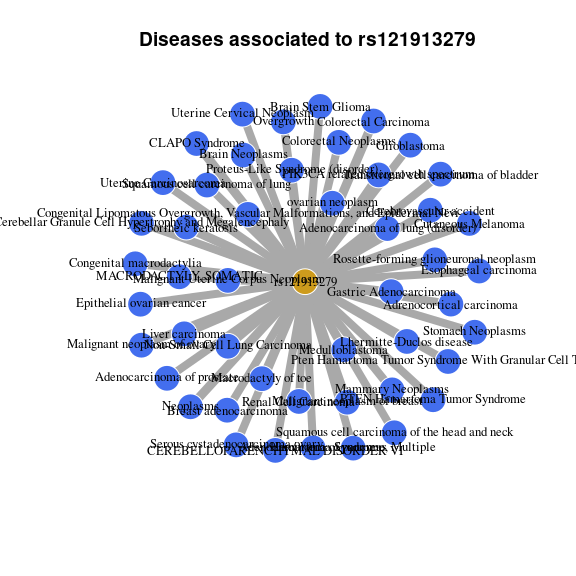

Figure 11: The **Variant-Disease Network** for the variant rs121913279

```r
plot( data6,
      class = "Network",
      prop  = 10)
```

The results can also be visualized in a network in which diseases are grouped by the MeSH Disease Class if the `class` argument is set to “DiseaseClass” (Figure 12). In the `Variant-Disease Class Network`, the node size of is proportional to the fraction of diseases in the disease class, with respect to the total number of diseases with disease class associated to the gene. In the example, the variant is associated mainly to Neoplasms.

```
## [1] "warning: 4 disease(s) not shown in the plot"
## [1] "warning: 4 disease(s) not shown in the plot"
```

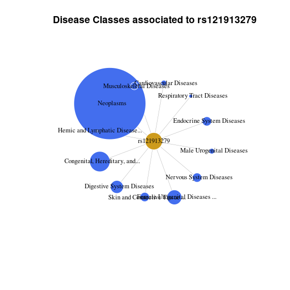

Figure 12: The **Variant- Disease Class Network** for the variant rs121913279

```r
plot( data6,
      class = "DiseaseClass",
      prop = 3)
```

### Exploring the evidences associated to a variant

You can extract the evidences associated to a particular variant using the function **variant2evidence**. Additionally, you can explore the evidences for a specific variant-disease pair by specifying the argument `disease`.

```
## Object of class 'DataGeNET.DGN'
##  . Search:      single
##  . Type:        evidence
##  . Database:     ALL
##  . Score:        0-1
##  . Term:        rs121913279
```

The results are shown in the table below.

Evidences supporting the association between C0009402 & rs121913279

| pmid | year | sentence |
| --- | --- | --- |
| 15994075 | 2005 | The prevalence of PIK3CA mutations in gastric and colon cancer. |
| 15930273 | 2005 | Functional analysis of PIK3CA gene mutations in human colorectal cancer. |
| 23826249 | 2013 | Collectively, our data suggest that PF-04691502 exhibits potent anticancer activity in colorectal cancer by targeting both PIK3CA (H1047R) mutant CSCs and their derivatives. |
| 27405731 | 2016 | We developed a sensitive, simple and rapid approach to detect the low-abundance PIK3CA (H1047R) mutation in real CRC specimens, providing an effective tool for guiding cancer targeted therapy. |

## Searching multiple variants

The **variant2disease** function retrieves the information in DisGeNET for a list of variants identified by the dbSNP identifier. The function also requires the user to specify the source database using the argument `database`. By default, **variant2disease** function uses as source database *CURATED*.

```r
data7 <- variant2disease(
         variant = c("rs121913013", "rs1060500621",
              "rs199472709", "rs72552293",
              "rs74315445", "rs199472795"),
         database = "ALL")
```

### Visualizing the diseases associated to multiple variants

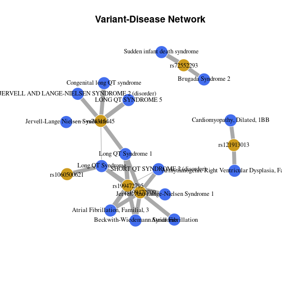

Figure 13: The **Variant-Disease Network** for a list of variants

```r
plot( data7,
      class = "Network",
      prop = 10)
```

To obtain the `Variant-Gene-Disease Network`, Figure 14), change the `showGenes` argument to “TRUE.”

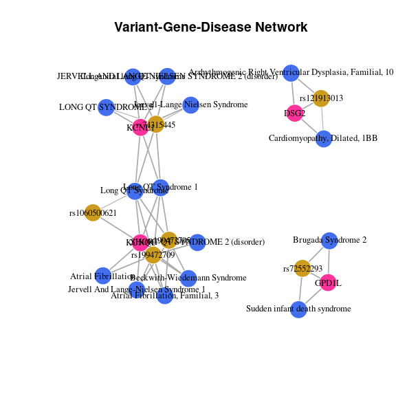

Figure 14: The **Variant-Gene-Disease Network** for a list of variants

```r
plot( data7,
      class = "Network",
      showGenes = T)
```

The results of querying DisGeNET variant information with a list of diseases can be visualized as a `Variant-Disease Heatmap` by changing the `class` argument to `Heatmap` (Figure 15).

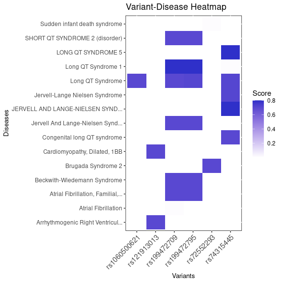

Figure 15: The **Variant-Disease Heatmap** for a list of variants

```r
plot( data7,
      class = "Heatmap",
      prop = 10)
```

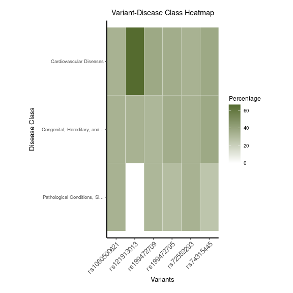

Figure 16: The **Variant-Disease Class Heatmap** for a list of variants

```r
plot( data7,
      class = "DiseaseClass")
```

## Searching by disease

The **disease2variant** function allows to retrieve the variants associated to a disease, or a list of diseases. The function uses as input the disease, or list of diseases of interest (as UMLS CUI, MeSH, OMIM, Disease Ontology, ICD9CM, NCIt, EFO, or Orphanet Identifiers), the disease vocabulary employed (`OMIM` (OMIM), `MESH` (MeSH),`ICD9CM` (ICD9-CM), `DO` (Disease Ontology), `NCI` (NCI thesaurus), `ORDO` (Orphanet), or `EFO` (EFO) and the database (by default, `CURATED`). A threshold value for the score can be set, like in the **gene2disease** function.

```r
data8 <- disease2variant(disease = c("C0752166"),
                       database = "CLINVAR",
                       score = c(0, 1) )
data8
```

```
## Object of class 'DataGeNET.DGN'
##  . Search:      single
##  . Type:        disease-variant
##  . Database:     CLINVAR
##  . Score:        0-1
##  . Term:        C0752166
##  . Results:  157
```

### Visualizing the variants associated to a single disease

The results of querying DisGeNET variant information with a list of diseases can be visualized as a `Variant-Disease Network` (Figure 17).

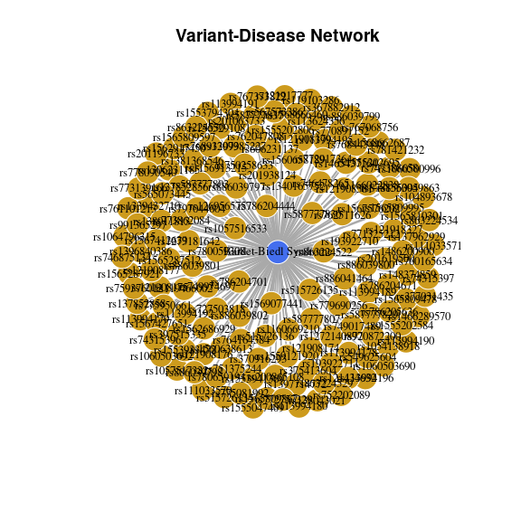

Figure 17: The **Variant-Disease Network** for a single disease

```r
plot( data8,
      class = "Network")
```

### Explore the evidences associated to a single disease

To explore the evidences supporting the VDAs for Schizophrenia, run the **disease2evidence** function. You can use the argument variant to inspect the evidences for a particular variant and Schizophrenia. You can also specify a year range for the publications

```r
data8 <- disease2evidence( disease  = "C0036341",
                               variant = "rs1344706",
                           type = "VDA",
                           year = c(2019, 2020),
                          database = "ALL",
                          score    = c( 0.1,1 ) )
data8
```

```
## Object of class 'DataGeNET.DGN'
##  . Search:      single
##  . Type:        evidence
##  . Database:     ALL
##  . Score:        0.1-1
##  . Term:        C0036341
```

Evidences supporting associations between C0036341 & rs1344706

| pmid | year | sentence |
| --- | --- | --- |
| 30852803 | 2019 | ZNF804A rs1344706 has been identified as one of the risk genes for schizophrenia. |
| 30962687 | 2019 | rs1344706 risk allele carriers of schizophrenia had increased gray matter in the brain regions including frontal lobe, temporal lobe, and other brain regions, but the carriers of healthy individuals h… |
| 30079586 | 2019 | CACNA1C-rs1006737 and ZNF804A-rs1344706 polymorphisms are among the most robustly associated with schizophrenia (SCZ) and bipolar disorder (BD), and recently with brain phenotypes. |
| 31122238 | 2019 | Previous studies indicated that single-nucleotide polymorphism (SNP) rs1344706 in ZNF804A was strongly associated with schizophrenia and might influence social interaction. |

If you want to inspect the evidences for Schizophrenia, and all the variants in a particular gene, use the argument `gene`.

```r
data8 <- disease2evidence( disease  = "C0036341",
                               gene = "CACNA1C",
                           type = "VDA",
                          database = "BEFREE",
                          score    = c( 0.1,1 ) )
data8
```

```
## Object of class 'DataGeNET.DGN'
##  . Search:      single
##  . Type:        evidence
##  . Database:     BEFREE
##  . Score:        0.1-1
##  . Term:        C0036341
```

```r
results <- extract(data8)
```

Selection of evidences supporting associations between C0036341 & CACNA1C

|  | pmid | year | sentence |
| --- | --- | --- | --- |
| 6 | 30607529 | 2019 | Both CACNA1C (rs1006737) and KCNH2 (rs3800779) were genotyped in 101 controls and 50 schizophrenia patients. |
| 8 | 31033230 | 2019 | We performed a comprehensive meta-analysis of all available samples from existing studies under four different genetic models (recessive model, dominant model, additive model and allele model) to furt… |
| 25 | 30079586 | 2019 | CACNA1C-rs1006737 and ZNF804A-rs1344706 polymorphisms are among the most robustly associated with schizophrenia (SCZ) and bipolar disorder (BD), and recently with brain phenotypes. |
| 27 | 30268820 | 2019 | Taken together, results of this study suggested that rs2007044 could affect the activation of the left IFG, which was a possible brain mechanism underlying the association between CACNA1C gene polymor… |
| 29 | 29599094 | 2018 | Three SNPs (rs1625579, rs1344706 and rs4765905) showed a consistent direction of effect with previous studies and the polygenic risk score constructed using the weighted sum of these three SNPs showed… |

## Searching multiple diseases

```r
data8 <- disease2variant(
              disease = c("C3150943",  "C1859062", "C2678485", "C4015695"),
              database = "CURATED",
              score = c(0.75, 1) )
data8
```

```
## Object of class 'DataGeNET.DGN'
##  . Search:      list
##  . Type:        disease-variant
##  . Database:     CURATED
##  . Score:        0.75-1
##  . Term:       C3150943 ... C4015695
##  . Results:  62
```

### Visualizing the variants associated to multiple diseases

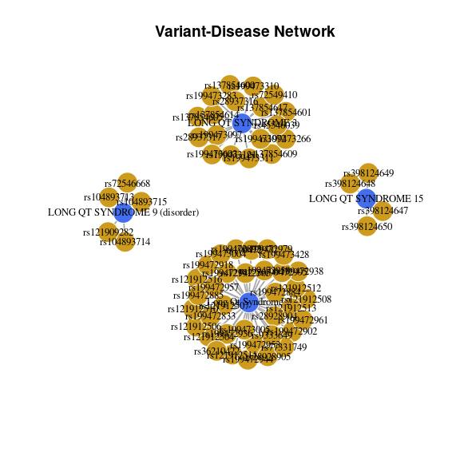

Figure 18: The **Variant-Disease Network** for a list of diseases

```r
plot( data8,
      class = "Network")
```

The `Variant-Disease Network` can be displayed as a `Variant-Disease-Gene Network`, by setting the `showGenes` parameter to `TRUE`.

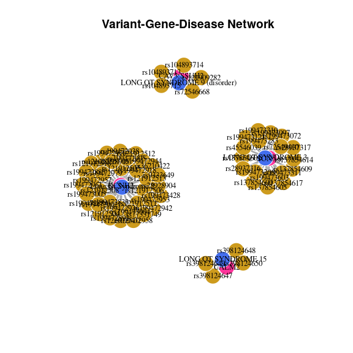

Figure 19: The **Variant-Gene-Disease Network** for a list of diseases

```r
plot( data8,
      class = "Network",
      showGenes = T)
```

The results can be visualized as a Heatmap.

```
## [1] "warning: dataframe of 62 rows has been reduced to 50 rows."
```

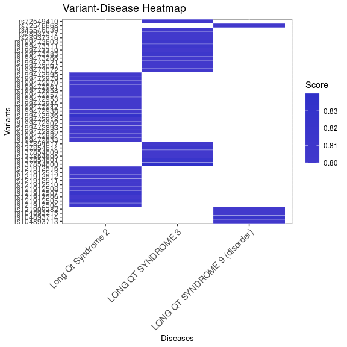

Figure 20: The **Variant-Disease Heatmap** for a list of diseases

```r
plot( data8,
      class = "Heatmap",
      prop = 10)
```

# Retrieving Disease-Disease Associations from DisGeNET

The **disgenet2r** package also allows to obtain a list of diseases that share genes or variants with a particular disease, or disease list (disease-disease associations, or DDAs).

## Searching DDAs by genes for a single disease

To obtain disease-disease associations, use the **disease2disease_by_gene** function. This function uses as input a disease, in the same format that in **disease2gene**, the database to perform the search (by default, *CURATED*), and the argument `ndiseases`, the number of diseases that share genes with the disease(s) of interest. By default `ndiseases = 10`. The output is a `DataGeNET.DGN` object that contains the top 10 diseases that share genes with the disease that has been searched.

```r
data9 <- disease2disease_by_gene(
  disease  = "C0010674",
  database = "CURATED", ndiseases = 5 )
data9
```

```
## Object of class 'DataGeNET.DGN'
##  . Search:      single
##  . Type:        disease-disease-gene
##  . Database:     CURATED
##  . Score:
##  . Term:        C0010674
##  . Results:  5
```

```r
qr <- extract(data9)
head(qr[c("disease1_name", "disease2_name","jaccard_genes","ngenes", "pvalue")])
```

```
##     disease1_name                                            disease2_name jaccard_genes ngenes pvalue
## 1 Cystic Fibrosis                                Pulmonary Cystic Fibrosis         0.818      9      0
## 2 Cystic Fibrosis                          Fibrocystic Disease of Pancreas         0.818      9      0
## 3 Cystic Fibrosis                                Idiopathic bronchiectasis         0.364      4      0
## 4 Cystic Fibrosis                                          Liddle Syndrome         0.250      3      0
## 5 Cystic Fibrosis BRONCHIECTASIS WITH OR WITHOUT ELEVATED SWEAT CHLORIDE 1         0.182      2      0
```

The `DataGeNET.DGN` object produced by the **disease2disease_by_gene** function also contains the Jaccard Index, also known as the Jaccard similarity coefficient for each disease pair. The Jaccard Coefficient is a similarity metric, computed as as the size of the intersection divided by the size of the union of two sample sets, in this case, the genes associates to each disease:

$$\begin{equation*}
J(A, B) = \frac{\mid A \cap B \mid}{\mid A \cup B \mid}
\end{equation*}$$

The `pvalue` column estimates the significance of the Jaccard coefficient for a list of disease pairs. The estimation of the pvalue is estimated by randomizing 1000 times.

### Visualizing the diseases associated to a single disease

The **plot** function applied to the `DataGeNET.DGN` object generated by the **disease2disease_by_gene** function results in a `Disease-Disease Network`, where the node in dark blue is the disease of interest and nodes in ligth blue are the diseases that share genes with it (Figure 21). The node size is proportional to the number of genes associated to each disease.

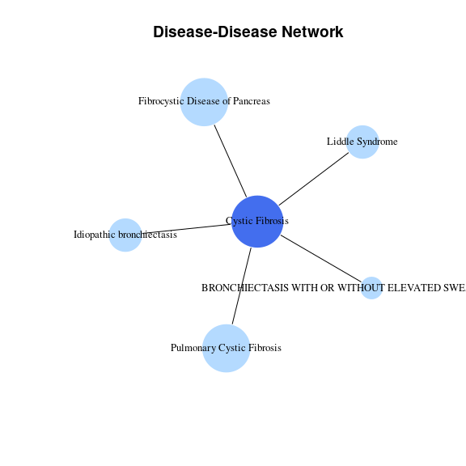

```r
plot( data9,
      class = "Network",
      layout="layout.lgl" ,
      prop = 0.4 )
```

To obtain the fully connected network, set the `class` argument of the **plot** function to `Diseasome`(Figure 22). In this network, the nodes are the diseases of interest, and the node size is proportional to the number of genes associated with them, and the edges size is proportional to the number of genes that are shared between the diseases they are connecting. The nodes in dark blue are the query diseases, and in light blue, the diseases that share genes with them.

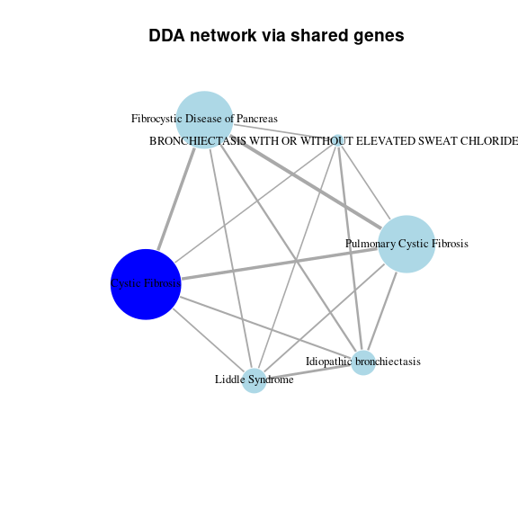

```r
plot( data9,
      class = "Diseasome",
      layout="layout.lgl" ,
      prop = 5 )
```

A second option to visualize the results of **disease2disease_by_gene** is as a `Disease-Disease Barplot` (Figure 23), obtained by setting the `class` argument to `Barplot`. The `Disease-Disease Barplot` shows the top **n** diseases that share genes with the disease of interest. This barplot also provides the jaccard index for each disease pair.

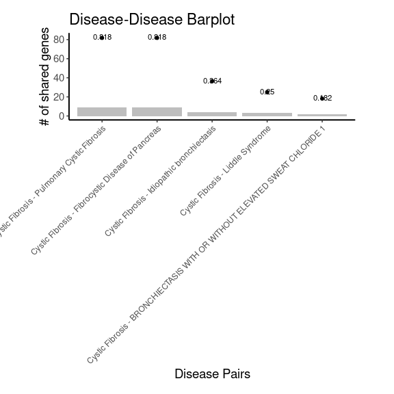

```r
plot( data9,
      class="Barplot")
```

## Searching DDAs via genes for multiple diseases

### Visualizing the diseases associated to multiple diseases

The function **disease2disease_by_gene** can receive a list of diseases as input, in any of the previously described vocabularies. It will retrieve the top 10 diseases that share genes with each of the diseases in the input list. This results can be visualized as a `Disease-Disease Network`, a `Diseasome plot`, or as a `Barplot`.

[output not shown]

```r
diseasesOfInterest <-  c("C0013182", "C0013221", "C3658290", "C0860207", "C1274933")
data10 <- disease2disease_by_gene(
  disease = diseasesOfInterest,
  database = "CURATED", ndiseases =  5)
```

To obtain the network, set the `class` argument of the **plot** function to `Network`(Figure 24). In this network, the nodes are the diseases of interest, and the node size is proportional to the number of genes associated with them. On the other hand, the edges size is proportional to the number of genes that are shared between the diseases they are connecting.

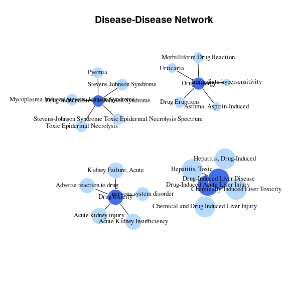

Figure 24: The **Disease-Disease Network** by shared genes for a list of diseases

```r
plot( data10,
      class = "Network",
      prop  = 0.1)
```

To obtain the fully connected network, set the `class` argument of the **plot** function to `Diseasome`(Figure 25). In this network, the nodes are the diseases of interest, and the node size is proportional to the number of genes associated with them. On the other hand, the edges size is proportional to the number of genes that are shared between the diseases they are connecting.

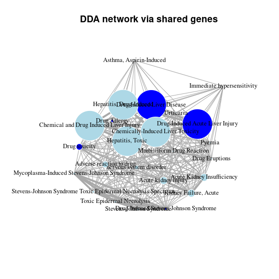

Figure 25: The **Diseasome plot** for a list of diseases

```r
plot( data10,
      class = "Diseasome",
      prop  = 0.1)
```

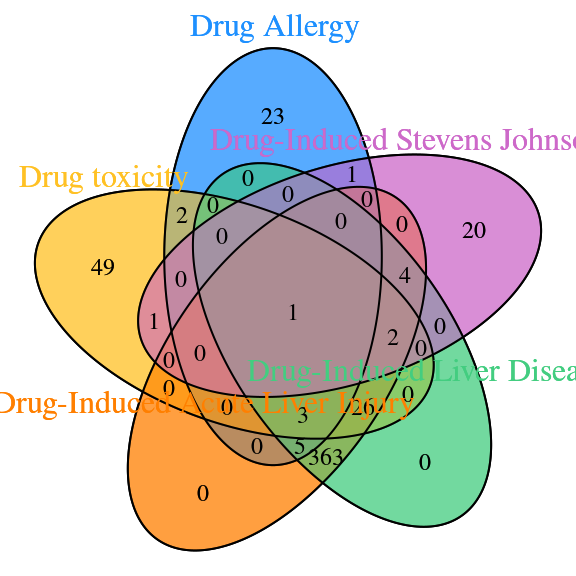

```r
plot( data10,
      class="Venn")
```

The Venn diagram for 4 diseases

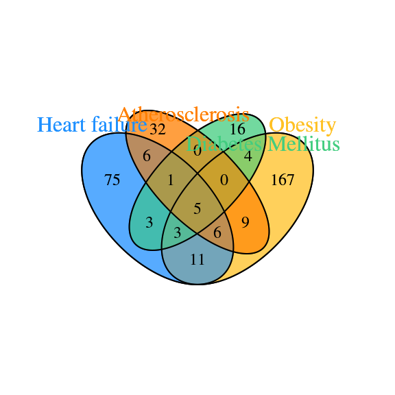

Figure 27: The **Venn Diagram** for a list of 4 diseases

```r
data11 <- disease2disease_by_gene(
  disease =  c("C0018801", "C0028754", "C0004153", "C0011849"),
  database = "CURATED",
  ndiseases = 5)
plot( data11,
      class="Venn"
)
```

The Venn diagram for 5 diseases

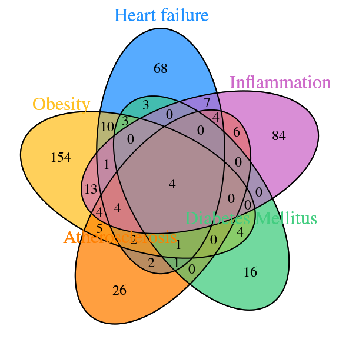

Figure 28: The **Venn Diagram** for a list of 5 diseases

```r
data11 <- disease2disease_by_gene(
  disease =  c("C0018801", "C0028754", "C0004153", "C0011849", "C0021368"),
  database = "CURATED",
  ndiseases = 5)
plot( data11,
      class="Venn"
)
```

## Searching DDAs via shared variants for a single disease

To obtain disease-disease associations, use the **disease2disease_by_variant** function. This function uses as input a disease, in the same format that in **disease2disease_by_gene**, the database to perform the search (by default, *CURATED*), and the argument `ndiseases`, the number of diseases that share genes with the disease(s) of interest. By default `ndiseases = 10`. The output is a `DataGeNET.DGN` object that contains the top 10 diseases that share genes with the disease that has been searched.

```r
data12 <- disease2disease_by_variant(
  disease  = "C0011860",
  database = "CURATED", ndiseases = 3 )
```

```
## A total of 168051 variants obtained from DisGeNET database CURATED are
##                  being used for the bootstrap process
```

```
## Pvalue estimation
```

```r
data12
```

```
## Object of class 'DataGeNET.DGN'
##  . Search:      single
##  . Type:        disease-disease-variant
##  . Database:     CURATED
##  . Score:
##  . Term:        C0011860
##  . Results:  3
```

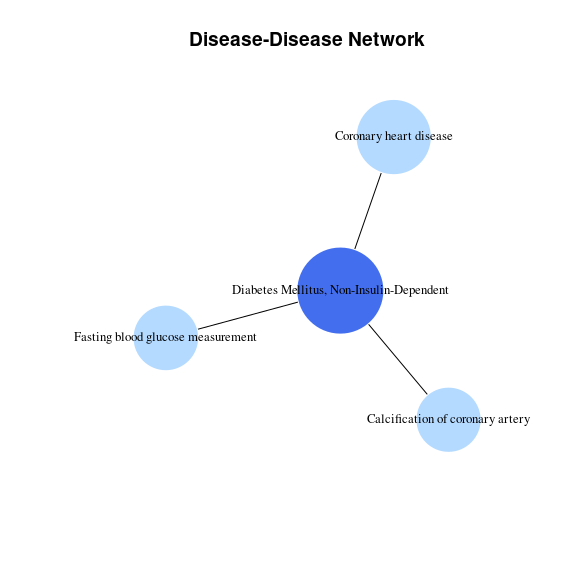

Figure 29: An example of **Disease-Disease Network**

```r
plot( data12, layout="layout.lgl" ,
      prop = 0.2 )
```

```r
data13 <- disease2disease_by_variant(
  disease  = c("C0018801", "C0020538"),
  database = "CURATED", ndiseases = 5 )

data13
```

```
## Object of class 'DataGeNET.DGN'
##  . Search:      list
##  . Type:        disease-disease-variant
##  . Database:     CURATED
##  . Score:
##  . Term:       C0018801 ... C0020538
##  . Results:  10
```

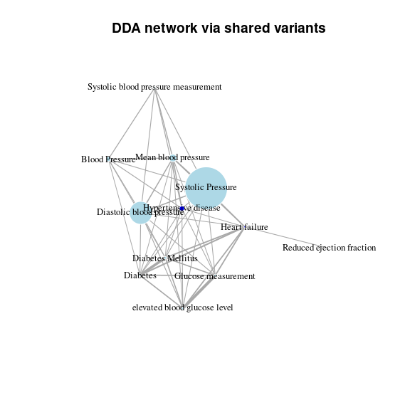

```r
plot( data13, layout="layout.lgl" ,
      class = "Diseasome",
      prop = 0.02)
```

# Performing a disease enrichment

The **disease_enrichment** function receives a list of genes and performs an enrichment analysis over the diseases in DisGeNET. The input list of genes should be identified with HGNC symbols, or Entrez Gene Identifiers. The vocabulary should be specified using the parameter `vocabulary`. By default, `vocabulary = "HGNC"`. The function has other optional argument: the source database (by default, `database = “CURATED”`). The background for the Fisher test are all the genes in DisGeNET. The p-values resulting from the multiple Fisher tests are corrected for false discovery rate using the Benjamini-Hochberg method.

To perform the enrichment, run:

```r
list_of_genes <- disease2gene(disease = "C0004352", database = "GENOMICS_ENGLAND")

list_of_genes <- list_of_genes@qresult$gene_symbol

res_enrich <-disease_enrichment( entities =list_of_genes, vocabulary = "HGNC",
                             database = "CURATED" )

table1 <- res_enrich@qresult[1:10, c("Description", "FDR", "Ratio",  "BgRatio")]
```

The column Ratio represents the number of genes from the input list that are associated to the disease. The BgRatio are the number of genes associated to the disease from the length of the universe, in the example, all genes in DisGeNET curated (9703).

| Description | FDR | Ratio | BgRatio |
| --- | --- | --- | --- |
| Autistic Disorder | 0.0000000 | 20/20 | 261/9703 |
| Intellectual Disability | 0.0000000 | 13/20 | 447/9703 |
| Global developmental delay | 0.0000003 | 7/20 | 133/9703 |
| Neurodevelopmental Disorders | 0.0000009 | 6/20 | 93/9703 |
| Autism Spectrum Disorders | 0.0000207 | 5/20 | 85/9703 |
| Abnormal behavior | 0.0001107 | 3/20 | 16/9703 |
| Seizures | 0.0014839 | 5/20 | 218/9703 |
| MENTAL RETARDATION, AUTOSOMAL DOMINANT 40 | 0.0029005 | 2/20 | 9/9703 |
| Schizophrenia | 0.0038198 | 8/20 | 883/9703 |
| Cardiovascular Abnormalities | 0.0076679 | 2/20 | 16/9703 |

To visualize the results of the enrichment, use the function **plot**. Use the argument `cutoff` to set a minimum p value threshold, and the argument `limit` to reduce the number of records shown. By default, `limit=50`. Use the argument `nchars` to control the lenght of the disease name.

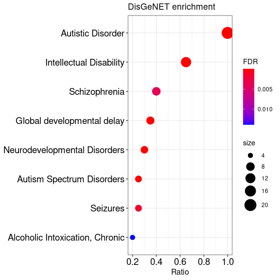

Figure : The **Enrichment plot** for a list of genes

```r
plot( res_enrich, class = "Enrichment", count =3,  cutoff= 0.05, nchars=70)
```

```r
res_enrich <-disease_enrichment( entities =list_of_genes, vocabulary = "HGNC",
                             database = "ALL" )

table1 <- res_enrich@qresult[1:10, c("Description", "FDR", "Ratio",  "BgRatio")]
```

| Description | FDR | Ratio | BgRatio |
| --- | --- | --- | --- |
| Autistic Disorder | 0.00e+00 | 20/20 | 1112/21666 |
| Neurodevelopmental Disorders | 0.00e+00 | 13/20 | 535/21666 |
| Intellectual Disability | 0.00e+00 | 18/20 | 2165/21666 |
| Pervasive Development Disorder | 0.00e+00 | 11/20 | 328/21666 |
| Global developmental delay | 0.00e+00 | 15/20 | 1825/21666 |
| Autism Spectrum Disorders | 0.00e+00 | 12/20 | 1071/21666 |
| Autistic behavior | 0.00e+00 | 8/20 | 261/21666 |
| Developmental delay (disorder) | 1.00e-07 | 9/20 | 584/21666 |
| Dysmorphic facies | 1.40e-05 | 6/20 | 271/21666 |
| Profound Mental Retardation | 3.03e-05 | 5/20 | 160/21666 |

To perform the enrichment, run:

```r
list_of_variants <- disease2variant(disease = "C0004352", database = "CLINVAR")

list_of_variants <- as.character(list_of_variants@qresult$variantid)

res_enrich <-disease_enrichment( entities =list_of_variants, vocabulary = "DBSNP",
                             database = "CURATED" )

table1 <- res_enrich@qresult[1:10, c("Description", "FDR", "Ratio",  "BgRatio")]
```

| Description | FDR | Ratio | BgRatio |
| --- | --- | --- | --- |
| Autistic Disorder | 0 | 69/69 | 181/168051 |
| Seizures | 0 | 22/69 | 417/168051 |
| Global developmental delay | 0 | 20/69 | 505/168051 |
| Generalized hypotonia | 0 | 14/69 | 164/168051 |
| Delayed speech and language development | 0 | 14/69 | 192/168051 |
| Poor school performance | 0 | 15/69 | 411/168051 |
| Constipation | 0 | 9/69 | 49/168051 |
| Mild Mental Retardation | 0 | 8/69 | 48/168051 |
| Aggressive behavior | 0 | 7/69 | 22/168051 |
| Acid reflux | 0 | 8/69 | 58/168051 |

To visualize the results of the enrichment, use the function **plot**. Use the argument `cutoff` to set a minimum p value threshold, and the argument `limit` to reduce the number of records shown. By default, `limit=50`.

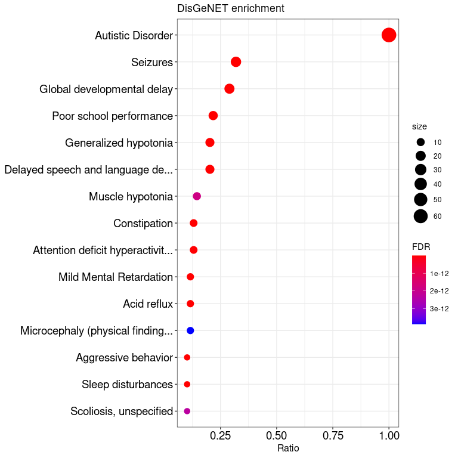

```r
plot( res_enrich, class = "Enrichment", count =6,  cutoff= 0.05)
```

# Expanding DisGeNET data with other resources available in the LOD cloud

Currently, Wikipathways-RDF has issues and these federated queries do not work!

## Retrieving the pathways associated to a disease

To obtain the pathways from WikiPathways associated to a disease, use the **disease2pathway** function.

```r
library("SPARQL")
dis2path <- disease2pathway( disease = "C0018801" ,
                             database = "ALL", score = c(0.5, 1))
dis2path
# head(dis2path@qresult)
# qr <- extract(dis2path)
# head(qr, 3)
```

## Retrieving the diseases associated to a given pathway

```r
path2dis <- pathway2disease( pathway = "WP1591" ,
                             database = "CURATED",
                             score = c(0.9, 1))
path2dis
head(path2dis@qresult)
qr <- extract(path2dis)
head(qr, 3)
```

## Retrieve the drug targets for a disease

The function **disease2compound** allows retrieved the chemicals in ChEMBL that target the genes associated to the given disease, or list of diseases. The function produces a DataGeNET.RDF object with the input disease(s), the associated genes, the DisGeNET score, and the chemicals associated to the disease proteins. If there were no chemicals found, the genes are still included in the output. It is important to higlight that because of ChEMBL restrictions for their SPARQL endpoint if 1000 compounds are retrieved for a single protein it probably means that there are more than 1000. (See more information about ChEMBL SPARQL endpoint at https://www.ebi.ac.uk/rdf/what-are-limitations-sparql-endpoints).

```r
dis2com <- disease2compound(
  disease = c("C0020538"),
  database = "CURATED" )
dis2com
qr <- extract(dis2com)
head(qr, 3)
```

## Retrieving Gene Ontology data for a gene

```r
gene2bp <- gene2biologicalprocess(gene = "351")
head(gene2bp@qresult)
gene2cc <- gene2cellcomponent(gene = "351")
head(gene2cc@qresult)
gene2mf <- gene2molecularfunction(gene = "351")
head(gene2mf@qresult)
gene2indi <- gene2indication( gene = "1588" )
head(gene2indi@qresult)
```

## Retrieving Gene Ontology data for a disease

The functions **disease2biologicalprocess**, **disease2molecularfunction**, and **disease2cellcomponent** can retrieve the Gene Ontology (GO) molecular function, GO biological process and GO cellular component of the genes associated to a disease or a list of diseases.

### Retrieving the biological processes associated to a disease

```r
disease2bp <- disease2biologicalprocess(
  disease = "C0036341",
  database = "CURATED",
  score = c( 0.6,1)
)
disease2bp
disease2bp <- extract(disease2bp)
head(disease2bp[c("gene_product_label","go_label")])
```

### Retrieving the molecular functions of the genes associated to a disease}

For a particular disease, the molecular activities of associated genes can be retrieved as GO terms using the function **disease2molecularfunction**. The function produces a DataGeNET.RDF object containing the disease, the genes and their GOMF terms.

```r
disease2mf <- disease2molecularfunction(
  disease = "C0002395",
  database = "UNIPROT"
)

disease2mf
disease2mf <- extract(disease2mf)
head(disease2mf[c("gene_product_label", "go_label")])
```

```r
disease2cc <- disease2cellcomponent(  disease = "C0002395",
                                      database = "MGD")

disease2cc <- extract(disease2cc)
head(disease2cc[c("gene_product_label", "go_label")])
```

# Get DisGeNET data version

```r
get_disgenet_version()
```

```
## [1] "{ api_version : 1.2.0 , database_version : DisGeNET Database v7 , lastUpdate : May 2021 , comments : - Added GDA and VDA evidences endpoints.- Added the disease similarity endpoint.- Added the disease mapping by name endpoint. }"
```

# COPYRIGHT

Copyright (C) 2021, IBI group.

disgenet2r is free software: you can redistribute it and/or modify it under the terms of the GNU General Public License as published by the Free Software Foundation, either version 3 of the License, or (at your option) any later version.

disgenet2r is distributed in the hope that it will be useful, but WITHOUT ANY WARRANTY; without even the implied warranty of MERCHANTABILITY or FITNESS FOR A PARTICULAR PURPOSE. See the GNU General Public License for more details.

You should have received a copy of the GNU General Public License along with this program. If not, see http://www.gnu.org/licenses/.

# How to cite disgenet2r

Piñero, J., Ramírez-Anguita, J. M., Saüch-Pitarch, J., Ronzano, F., Centeno, E., Sanz, F., & Furlong, L. I. (2020). The DisGeNET knowledge platform for disease genomics: 2019 update. Nucleic Acids Research, 48(D1), D845-D855.

# References

Bravo, J. Piñero, N. Queralt-Rosinach, M. Rautschka, and L. I. Furlong. 2015. “Extraction of relations between genes and diseases from text and large-scale data analysis: Implications for translational research.” *BMC Bioinformatics* 16 (1). https://doi.org/10.1186/s12859-015-0472-9.

Bundschus, Markus, Mathaeus Dejori, Martin Stetter, Volker Tresp, and Hans-Peter Kriegel. 2008. “Extraction of semantic biomedical relations from text using conditional random fields.” *BMC Bioinformatics* 9 (1): 207. https://doi.org/10.1186/1471-2105-9-207.

Piñero, J., A. Bravo, N. Queralt-Rosinach, A. Gutiérrez-Sacristán, J. Deu-Pons, E. Centeno, J. García-García, F. Sanz, and L. I. Furlong. 2017. “DisGeNET: A comprehensive platform integrating information on human disease-associated genes and variants.” *Nucleic Acids Research* 45 (D1). https://doi.org/10.1093/nar/gkw943.

Piñero, J., N. Queralt-Rosinach, À. Bravo, J. Deu-Pons, A. Bauer-Mehren, M. Baron, F. Sanz, and L. I. Furlong. 2015. “DisGeNET: A discovery platform for the dynamical exploration of human diseases and their genes.” *Database* 2015. https://doi.org/10.1093/database/bav028.

Piñero, Janet, Juan Manuel Ramírez-Anguita, Josep Saüch-Pitarch, Francesco Ronzano, Emilio Centeno, Ferran Sanz, and Laura I Furlong. 2019. “The DisGeNET knowledge platform for disease genomics: 2019 update.” *Nucleic Acids Research*, November. https://doi.org/10.1093/nar/gkz1021.

Queralt-Rosinach, N., J. Piñero, À. Bravo, F. Sanz, and L. I. Furlong. 2016. “DisGeNET-RDF: Harnessing the innovative power of the Semantic Web to explore the genetic basis of diseases.” *Bioinformatics* 32 (14). https://doi.org/10.1093/bioinformatics/btw214.